# **Kia and Hyundai Share of Milwaukee Thefts in 2022**

By 2022, nearly three of every five cars stolen in Milwaukee were a Kia or Hyundai. A simple two-slice pie makes that share impossible to miss for a non-technical audience.

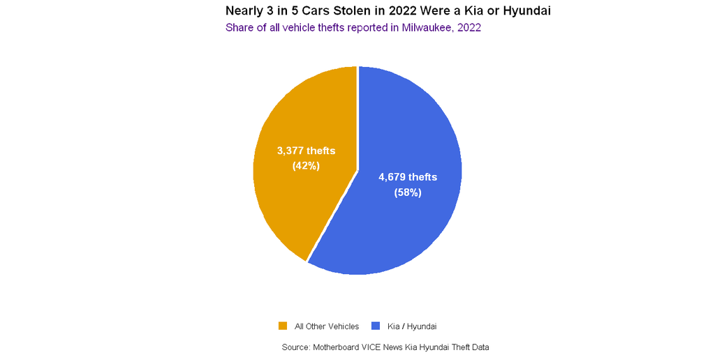

### **Kia and Hyundai Share of Milwaukee Thefts in 2019**

The same measure three years earlier gives the council the before picture. In 2019, Kia and Hyundai thefts were a small fraction of the total. Pairing this donut with the pie above shows the shift from roughly one in twenty to nearly three in five.

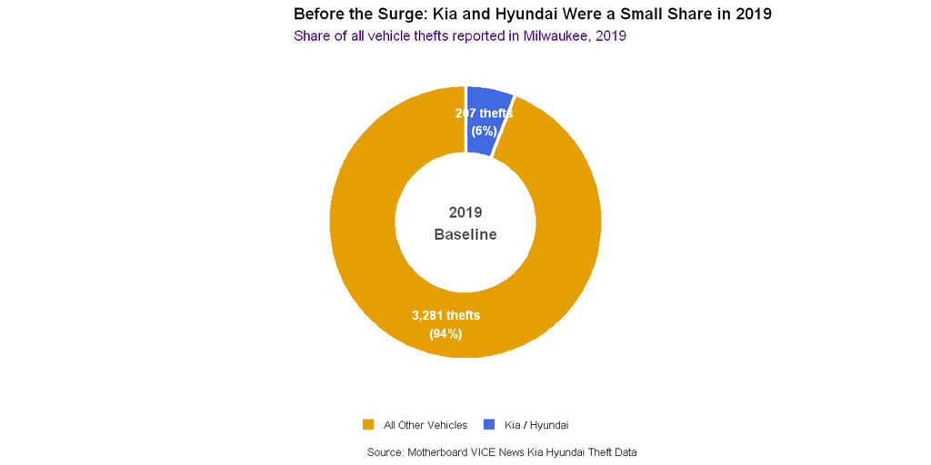

### **2022 Thefts by City, Kia and Hyundai vs. All Other Vehicles**

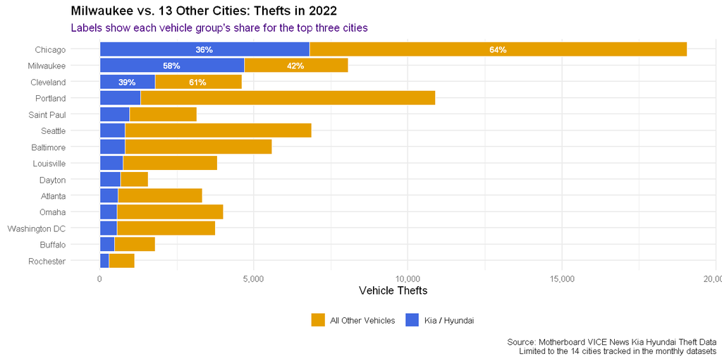

### **2022 Kia and Hyundai Thefts Across All Tracked Cities**

The VICE dataset tracks roughly 70 cities, far more than the monthly files. A treemap sizes each city by its 2022 Kia and Hyundai theft count, letting the council see the entire national landscape in one view and Milwaukee's outsized footprint within it. Cities with no reported Kia and Hyundai counts in 2022 are excluded and noted below the chart.

```
🔎 Cities with 2022 Kia/Hyundai data: 68
🔎 Milwaukee present: TRUE
```

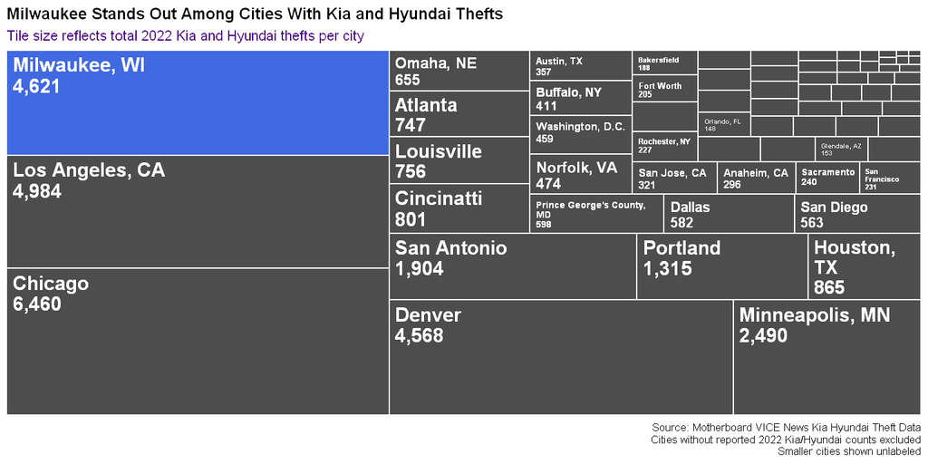

### **Milwaukee Kia and Hyundai Thefts by Month, 2019 to 2022**

The timeline answers the council's natural question: when did this start? Monthly Kia and Hyundai thefts in Milwaukee sat near twenty per month for nearly two years, then doubled every month starting in October 2020, from 39 in September to 406 by December. Milwaukee was not swept up in a national trend; the wave started here, months before it spread to other cities. The filled area emphasizes the cumulative volume of stolen vehicles, not just the trend.

[figure not shown]

### **The Theft Surge Is Mostly a Kia and Hyundai Surge**

The final visual stacks Kia and Hyundai thefts against all other vehicle thefts across the 14 tracked cities, month by month. Thefts of other vehicles rose modestly over the four years, but the Kia and Hyundai band grew from a sliver to nearly half the total by late 2022. Most of the surge traces to two brands with a known, fixable vulnerability, which means targeted measures like steering wheel locks and software updates can reverse the bulk of it.

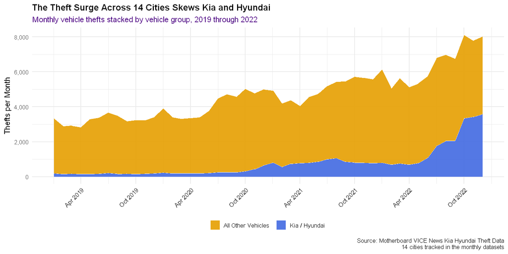

### **Call to Action**

The data supports one conclusion: Milwaukee's theft surge is concentrated in two brands with a known, fixable vulnerability, and Milwaukee has lived with it longer than any other city. The ask for the Common Council is specific:

**Approve funding for a two-part Vehicle Theft Prevention Initiative:**

1. **Free steering wheel lock distribution** targeted to registered owners of 2011-2021 Kia and Hyundai models, prioritized by the neighborhoods with the highest theft counts. Locks are an immediate, proven physical deterrent available for under $50 per vehicle.
2. **City-sponsored software update clinics** in partnership with local Kia and Hyundai dealers, bringing the manufacturers' free anti-theft software patch to owners who cannot easily reach a dealership. The patch closes the ignition vulnerability these thefts exploit.

Every month of delay costs Milwaukee hundreds of stolen vehicles, insurance claims, police hours, and residents stranded without transportation. The fix is known, inexpensive, and waiting on approval.